# DataChallenge2 | Mario Saraiva (mhs2195)

Mario Saraiva (mhs2195)

3/20/2018

GR5069 - TOPICS IN APPLIED DATA SCIENCE FOR SOCIAL SCIENTISTS - Spring 2018

March 20, 2018

```r
options(java.parameters = "-Xmx5g")
```

# Data Challenge 2

## Q.1

`Is there an association between Poverty/development levels, Lethality index, and number of deaths per conflict? I hypothesis that there is a difference between Perfect Lethality rate between poor and non-poor states in Mexico.`

### Lasso

Lasso regression is run on perfect_lethality against all numeric variables in our dataset:

**Interpreting the Lasso Graph:**

The colored line represents the value taken by a different coefficient in model 1. Lambda is the weight given to the regularization term (the L1 norm), so as lambda approaches zero, the loss function of your model approaches the OLS loss function. As lambda becomes larger, the regularization term has a greater effect and you will see fewer variables in your model. Our ideal lambda is the one that minimizes the residuals. In this case, a log of lambda of approximately -5 seems to be appropriate, as seen in the subsequent graph with MSE.

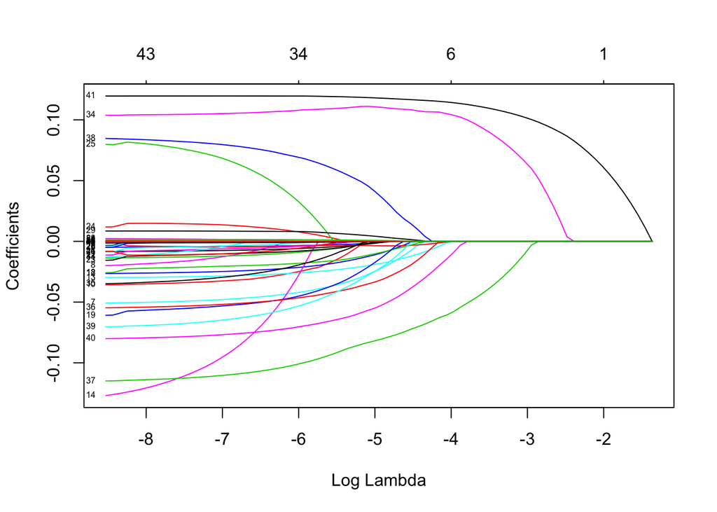

```r
#Remove variables not suited for Lasso:
# [5] "state"
# [6] "state_abbr"
# [8] "municipality"
# [45] "source"
# [46] "organized_crime_lethality"
# [47] "army_lethality"
# [48] "navy_lethality"
# [49] "federal_police_lethality"
# [54] "organized_crime_NewIndex"
# [55] "army_NewIndex"
# [56] "navy_NewIndex"
# [57] "federal_police_NewIndex"
# [59] "category"
# [60] "global_id"
# [64] "Level.Social.Lag.2005"


### We first set up x and y
slim.dta.pov <- dta.pov[,-c(1,2,5,6,8,45,46,47,48,49,54,55,56,57,59,60,62,64)]

slim.dta.pov <- na.omit(slim.dta.pov)

set.seed(12345) # = Seed for replication

x <- model.matrix(perfect_lethality ~ ., data = slim.dta.pov)[,-46]
y <- slim.dta.pov$perfect_lethality

### We then fit a Lasso regression model (alpha = 1)
fit.lasso <- glmnet(x, y, alpha = 1, family = "gaussian")
plot(fit.lasso, xvar = "lambda", label = TRUE)
```

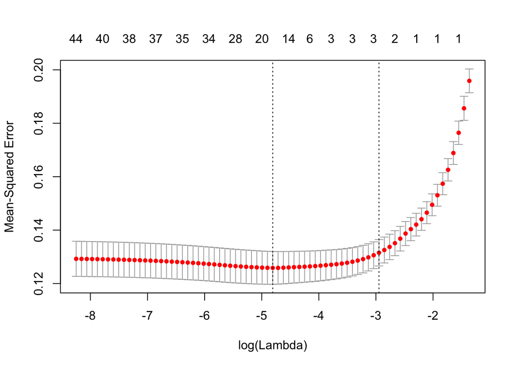

```r
### Now we cross-validate
cv.lasso <- cv.glmnet(x, y)
plot(cv.lasso)
```

Below are the 18 predictors of Perfect Lethality that collectively minimize mean squared error. Out of 70 variables, only 18 seem to be ideal candidates for predictors of perfect lethality.

| Num | Variable | Lasso coefficient |
| --- | --- | --- |
| 1 | detained | -0.0003073193 |
| 2 | military_dead | -0.0184931882 |
| 3 | ministerial_police_dead | -0.0074495572 |
| 4 | municipal_police_dead | -0.0166922238 |
| 5 | civilian_dead | -0.0001098928 |
| 6 | total_people_wounded | -0.0037244742 |
| 7 | military_wounded | -0.0074350113 |
| 8 | navy_wounded | -0.0081752818 |
| 9 | small_arms_seized | 0.0030058344 |
| 10 | army | 0.1096297637 |
| 11 | ministerial_police | -0.0286733220 |
| 12 | municipal_police | -0.0784595966 |
| 13 | navy | 0.0298730962 |
| 14 | other | -0.0166464452 |
| 15 | state_police | -0.0492937858 |
| 16 | organized_crime_lethality_diff | 0.1175320252 |
| 17 | Vulnerables.SocialCare.Pct.2010 | -0.0000926747 |
| 18 | Access.Health.Services.pct | 0.0006595007 |

### Regressing perfect lethality on significant predictors

```r
### Regression with all variables
model.1 <- glm(perfect_lethality ~ detained + military_dead + ministerial_police_dead + municipal_police_dead + civilian_dead + total_people_wounded + military_wounded + navy_wounded + small_arms_seized + army + ministerial_police + municipal_police + navy + other + state_police + organized_crime_lethality_diff + `Vulnerables.SocialCare.Pct.2010` + Access.Health.Services.pct, family = binomial(link="logit"), data = dta.pov)

summary(model.1)
```

```
##
## Call:
## glm(formula = perfect_lethality ~ detained + military_dead +
##     ministerial_police_dead + municipal_police_dead + civilian_dead +
##     total_people_wounded + military_wounded + navy_wounded +
##     small_arms_seized + army + ministerial_police + municipal_police +
##     navy + other + state_police + organized_crime_lethality_diff +
##     Vulnerables.SocialCare.Pct.2010 + Access.Health.Services.pct,
##     family = binomial(link = "logit"), data = dta.pov)
##
## Deviance Residuals:
##     Min       1Q   Median       3Q      Max
## -8.4904  -0.3963  -0.2872   0.0062   3.2782
##
## Coefficients:
##                                  Estimate Std. Error z value Pr(>|z|)
## (Intercept)                     -2.615077   0.277719  -9.416  < 2e-16 ***
## detained                         0.001155   0.025093   0.046   0.9633
## military_dead                   -0.625257   0.355562  -1.759   0.0787 .
## ministerial_police_dead         -0.412567   0.339042  -1.217   0.2237
## municipal_police_dead           -0.058408   0.183148  -0.319   0.7498
## civilian_dead                   -0.080882   0.149684  -0.540   0.5890
## total_people_wounded            -0.541004   0.069383  -7.797 6.32e-15 ***
## military_wounded                 0.227644   0.141696   1.607   0.1082
## navy_wounded                    -0.184586   0.523060  -0.353   0.7242
## small_arms_seized                0.026687   0.031137   0.857   0.3914
## army                             0.660978   0.141499   4.671 2.99e-06 ***
## ministerial_police               0.264904   0.228145   1.161   0.2456
## municipal_police                -0.116540   0.183220  -0.636   0.5247
## navy                             0.456907   0.357637   1.278   0.2014
## other                           -0.525305   0.406856  -1.291   0.1967
## state_police                    -0.015580   0.226983  -0.069   0.9453
## organized_crime_lethality_diff   2.541381   0.092066  27.604  < 2e-16 ***
## Vulnerables.SocialCare.Pct.2010 -0.004308   0.006822  -0.631   0.5277
## Access.Health.Services.pct       0.009524   0.005412   1.760   0.0785 .
## ---
## Signif. codes:  0 '***' 0.001 '**' 0.01 '*' 0.05 '.' 0.1 ' ' 1
##
## (Dispersion parameter for binomial family taken to be 1)
##
##     Null deviance: 5045.4  on 4333  degrees of freedom
## Residual deviance: 2089.4  on 4315  degrees of freedom
## AIC: 2127.4
##
## Number of Fisher Scoring iterations: 25
```

Interpretation:

Only the statistically significant coefficients will be addressed.

It is the estimated amount by which the log odds of leaves.presence would increase if Area were one unit higher.

1. Total_people_wounded: On average, a one unit increase in the total people wounded ratio is associated with a **decrease** in the log odds **of 0.541004** of having a perfect lethality event.
2. Army: On average, the presence of the army is associated with a **increase** in the log odds **0.660978** of having a perfect lethality event.
3. Organized_crime_lethality_diff: On average, a one unit increase in the difference in organized crime lethality is associated with a **increase** in the log odds __of 2.541381__of having a perfect lethality event.

The first three coefficients are statistically significant at the 0.000 level. In other words, the results we see are unlikely to be caused by luck. The following to coefficients are fairly weak statistically speaking but they present substantive insights.

4. Military_dead: On average, each additional death in the military is associated with a **decrease** in the log odds **of 0.6252574** of having a perfect lethality event.
5. Access.Health.Services.pct: On average, each additional death in the military is associated with a **increase** in the log odds **of 0.009524** of having a perfect lethality event.

### Visualization

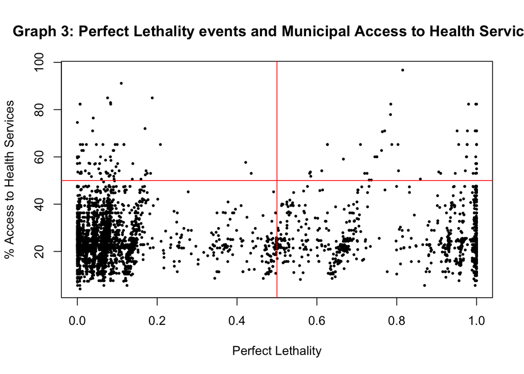

```r
set.seed(12345)
ypredict <- predict(model.1, type = "response")

plot(ypredict, dta.pov$Access.Health.Services.pct, pch = 16, xlab="Perfect Lethality", ylab="% Access to Health Services", title("Graph 3: Perfect Lethality events and Municipal Access to Health Services"), cex = .5)
abline(h = 50, v = .5, col = "red")
```

Graph 4 further supports our finding from the logit regression.

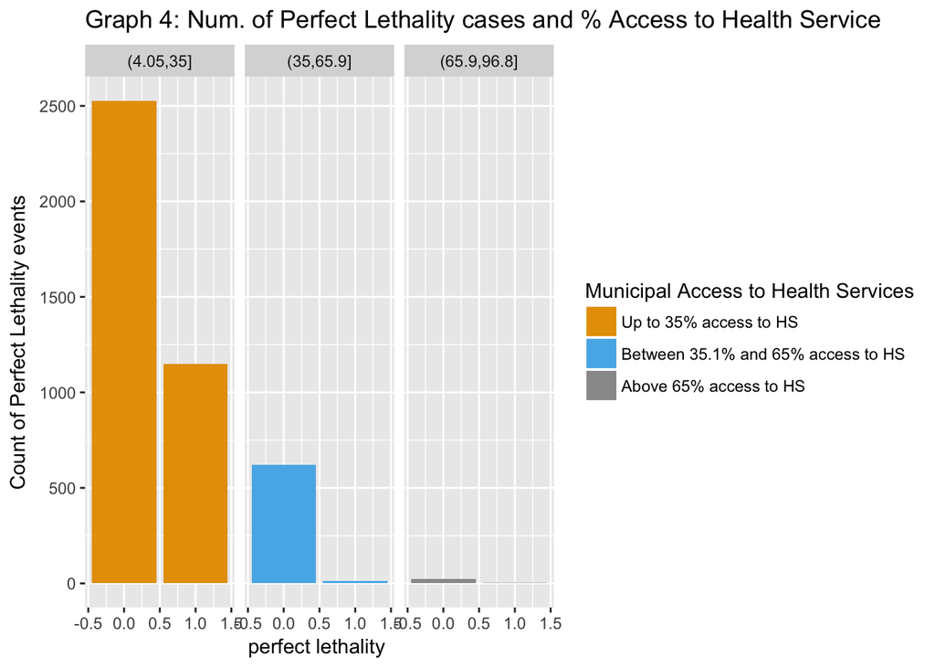

```r
plot.gg <- ggplot(dta.pov)

plot.gg + geom_bar(aes(dta.pov$perfect_lethality, fill = cut(Access.Health.Services.pct,3)))  + ggtitle("Graph 4: Num. of Perfect Lethality cases and % Access to Health Service") + xlab("perfect lethality ") + ylab("Count of Perfect Lethality events") + facet_wrap(~cut(Access.Health.Services.pct,3)) + scale_fill_manual( values=c("#E69F00", "#56B4E9", "#999999"),
                       name="Municipal Access to Health Services",
                       labels=c("Up to 35% access to HS", "Between 35.1% and 65% access to HS", "Above 65% access to HS"))
```

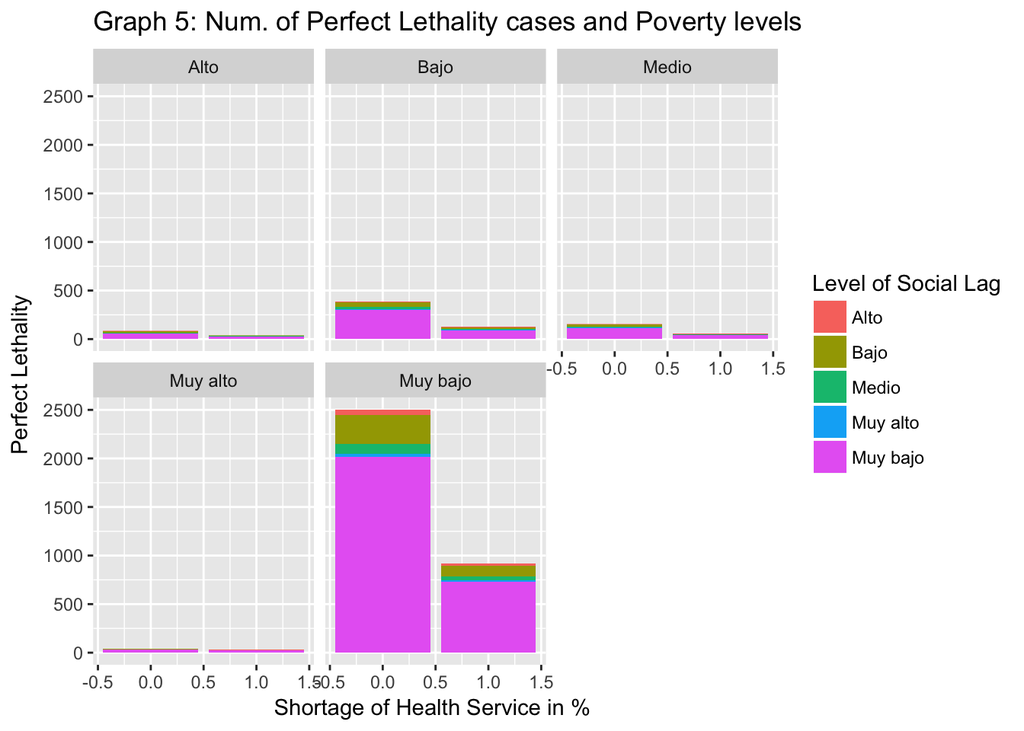

```r
plot.gg + geom_bar(aes(dta.pov$perfect_lethality, fill = dta.pov$Level.Social.Lag.2005))  + ggtitle("Graph 5: Num. of Perfect Lethality cases and Poverty levels") + xlab("Shortage of Health Service in % ") + ylab("Perfect Lethality")  + facet_wrap(~dta.pov$Level.Social.Lag.2005) + scale_fill_discrete(name = "Level of Social Lag")
```

```r
 # + scale_fill_manual( values=c("#E69F00", "#56B4E9", "#999999"),
 #                       name="Poverty Level",
 #                       labels=c("Up to 36% are poor", "Between 36.1% and 67% are poor", "Above 67% are poor"))
```